# Clustering Ecoli Data

2022-08-03

# Things to do:

# Load Necessary Packages

```r
library(dplyr)
```

```r
library(ggplot2)
```

# Read In The Data

```r
df <- read.csv("ecoli.csv")
```

# Explorartoy Data Analysis

Starting with the structure of the dataframe.

```r
glimpse(df)
```

```
## Rows: 336
## Columns: 8
## $ mcg   <dbl> 0.49, 0.07, 0.56, 0.59, 0.23, 0.67, 0.29, 0.21, 0.20, 0.42, 0.42…
## $ gvh   <dbl> 0.29, 0.40, 0.40, 0.49, 0.32, 0.39, 0.28, 0.34, 0.44, 0.40, 0.24…
## $ lip   <dbl> 0.48, 0.48, 0.48, 0.48, 0.48, 0.48, 0.48, 0.48, 0.48, 0.48, 0.48…
## $ chg   <dbl> 0.5, 0.5, 0.5, 0.5, 0.5, 0.5, 0.5, 0.5, 0.5, 0.5, 0.5, 0.5, 0.5,…
## $ aac   <dbl> 0.56, 0.54, 0.49, 0.52, 0.55, 0.36, 0.44, 0.51, 0.46, 0.56, 0.57…
## $ alm1  <dbl> 0.24, 0.35, 0.37, 0.45, 0.25, 0.38, 0.23, 0.28, 0.51, 0.18, 0.27…
## $ alm2  <dbl> 0.35, 0.44, 0.46, 0.36, 0.35, 0.46, 0.34, 0.39, 0.57, 0.30, 0.37…
## $ class <chr> "cp", "cp", "cp", "cp", "cp", "cp", "cp", "cp", "cp", "cp", "cp"…
```

The data has 8 variables and 336 observations. Futhermore, the data has exactly 0 missing values.

## Class

The class variable is the assigned label for the observation. The possible values are:

1. **cp** - Cytoplasm
2. **im** - Inner membrane without signal sequence
3. **pp** - Perisplasm
4. **imU** - Inner membrane, uncleavable signal sequence
5. **om** - outer membrane
6. **omL** - outer membrane lipoprotein
7. **imL** - inner membrane lipoprotein
8. **imS** - inner membrane, cleavable signal sequence

The classes are very imbalanced.

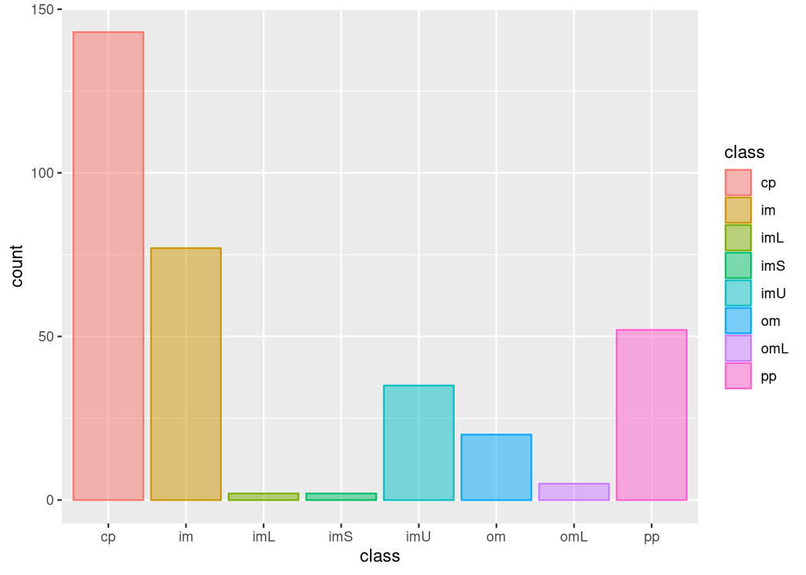

```r
ggplot(df, aes(x = class, color = class, fill = class)) + geom_bar(alpha = 0.5)
```

## MCG (McGeoch’s Method SSR)

The MCG variable refers to McGeoch’s method for signal sequence recognition (SSR).

The variable is quantitative in nature.

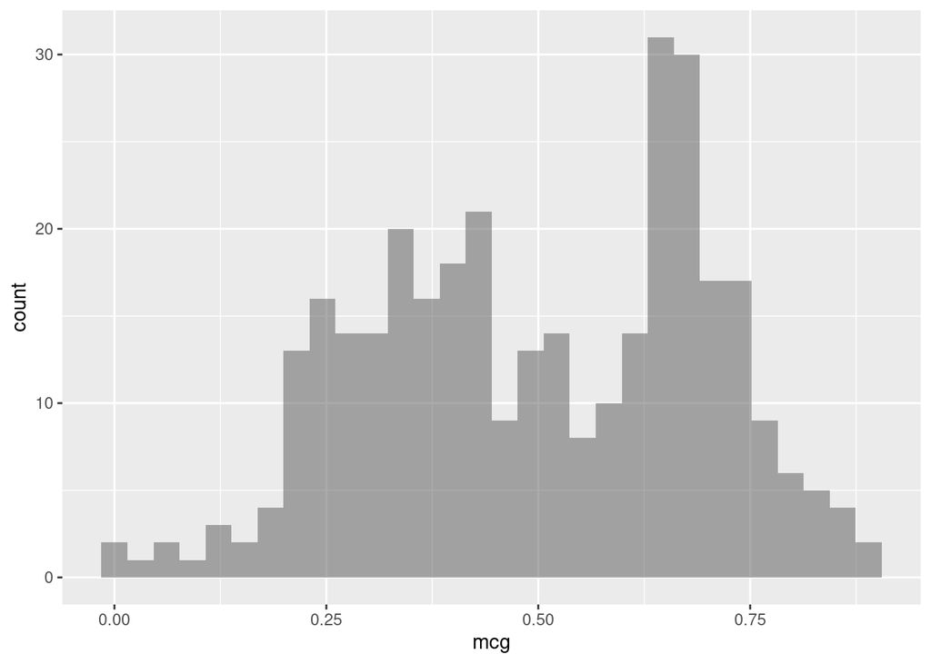

```r
ggplot(df, aes(x = mcg)) + geom_histogram(alpha = 0.5)
```

The variable appears to be bi-modal in nature, with peaks around 0.375 and 0.625. Additionally, the variable has a median of 0.5, a min of 0, and a maximum of 0.89.

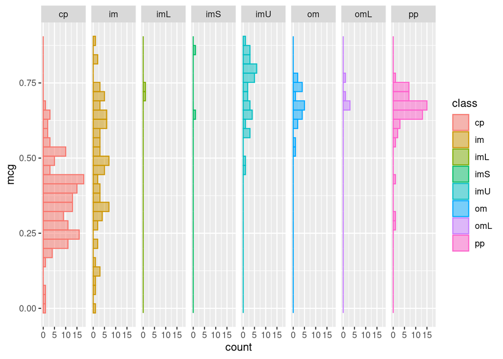

```r
ggplot(df, aes(x = mcg, fill = class, color = class)) + geom_histogram(alpha = 0.5) + facet_grid(~ class) + coord_flip()
```

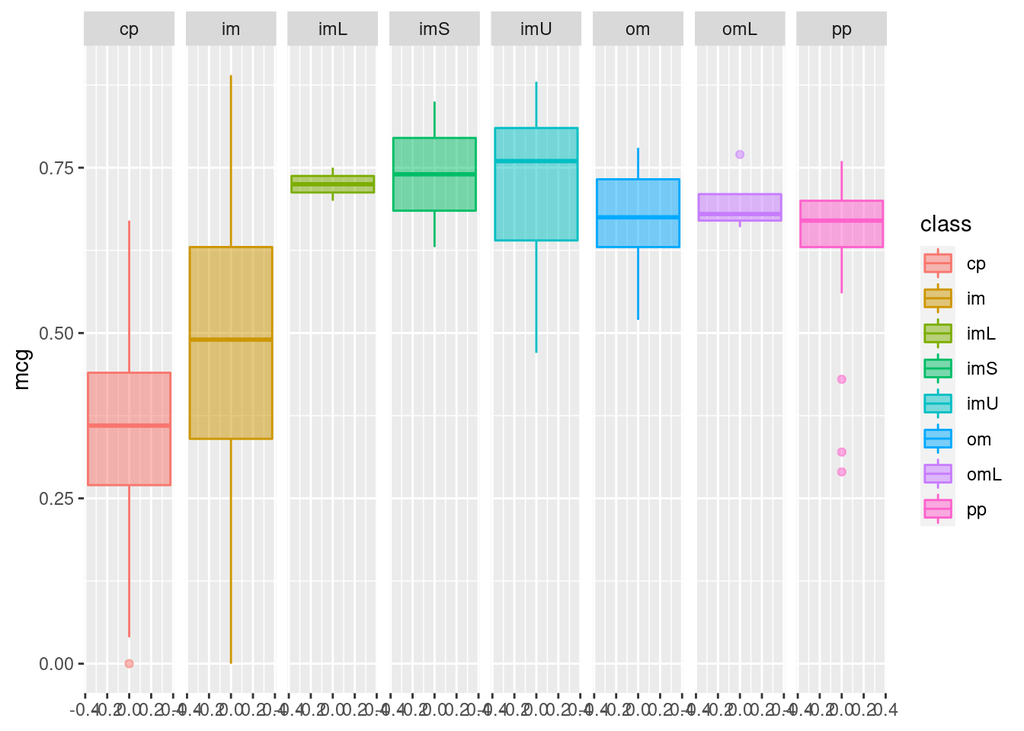

```r
ggplot(df, aes(x = mcg, fill = class, color = class)) + geom_boxplot(alpha = 0.5) + facet_grid(~ class) + coord_flip()
```

When the variable is compared by classes, it appears that both the CP is the only variable that places the median for MCG below 0.5, the IM variable places the median at approximately .5, and the remaining classes place the variable above 0.5.

## GVH (von Heijne’s Method SSR)

The GVH variable refers to von Heijne’s method for signal sequence recognition. The variable is quantitative in nature.

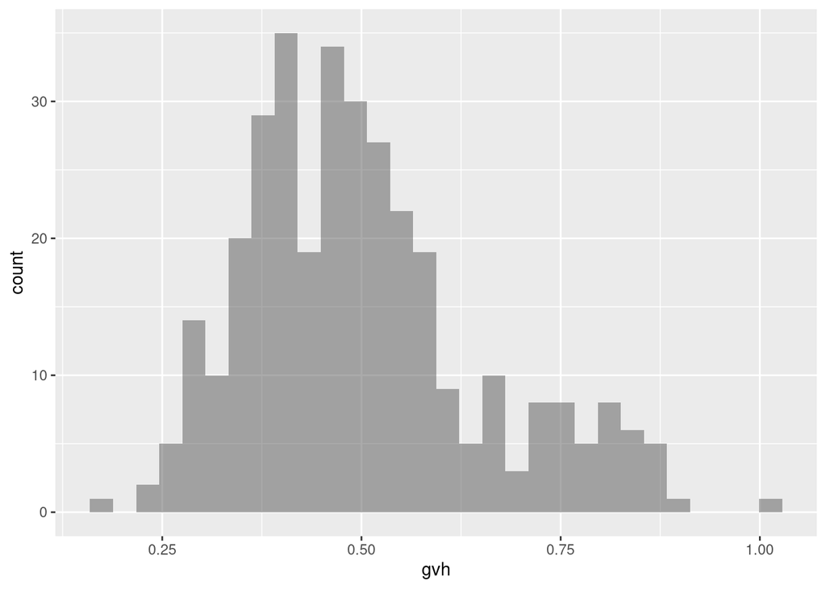

```r
ggplot(df, aes(x = gvh)) + geom_histogram(alpha = 0.5)
```

The variable appears to have a right skew, with a median of 0.47, a minimum of 0.16, and a maximum of 1.

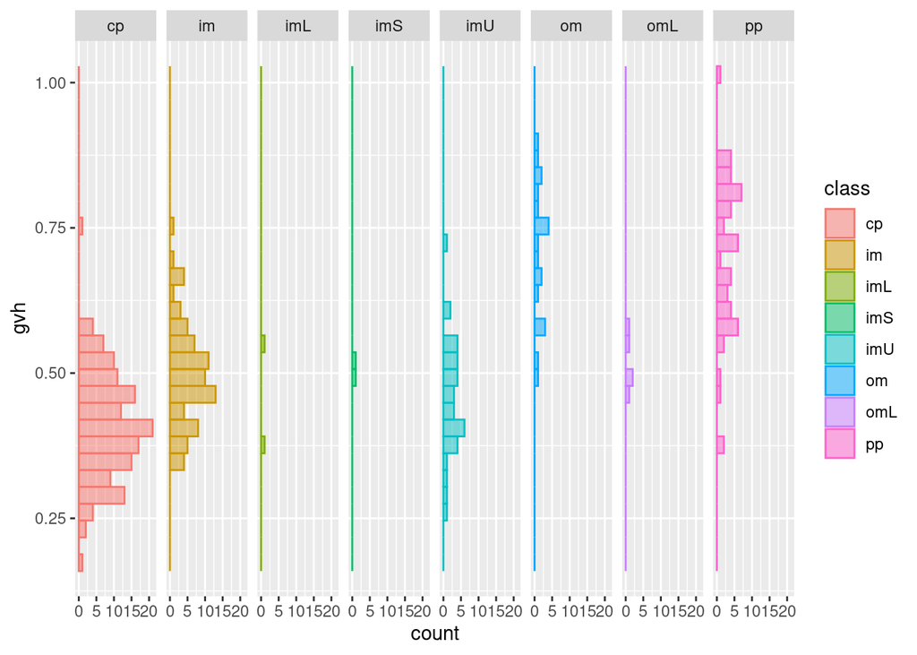

```r
ggplot(df, aes(x = gvh, fill = class, color = class)) + geom_histogram(alpha = 0.5) + facet_grid(~ class) + coord_flip()
```

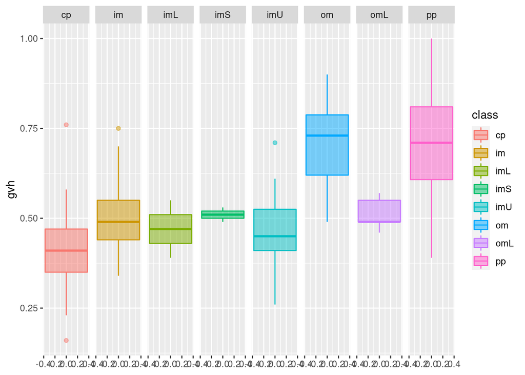

```r
ggplot(df, aes(x = gvh, fill = class, color = class)) + geom_boxplot(alpha = 0.5) + facet_grid(~ class) + coord_flip()
```

## LIP (von Heijne’s Signal Piptidase II Score)

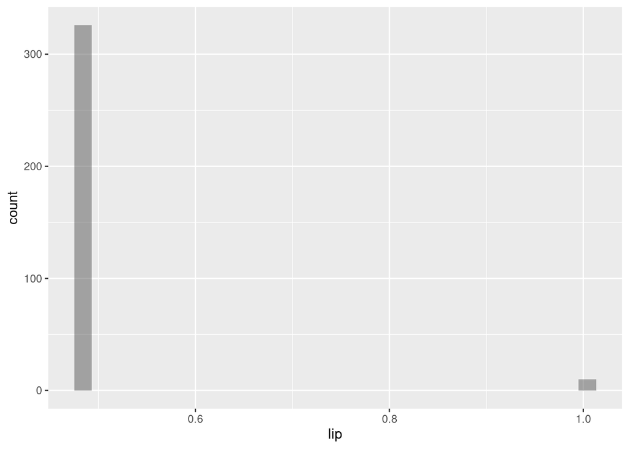

```r
ggplot(df, aes(x = lip, color = lip, fill = lip)) + geom_histogram(alpha = 0.5)
```

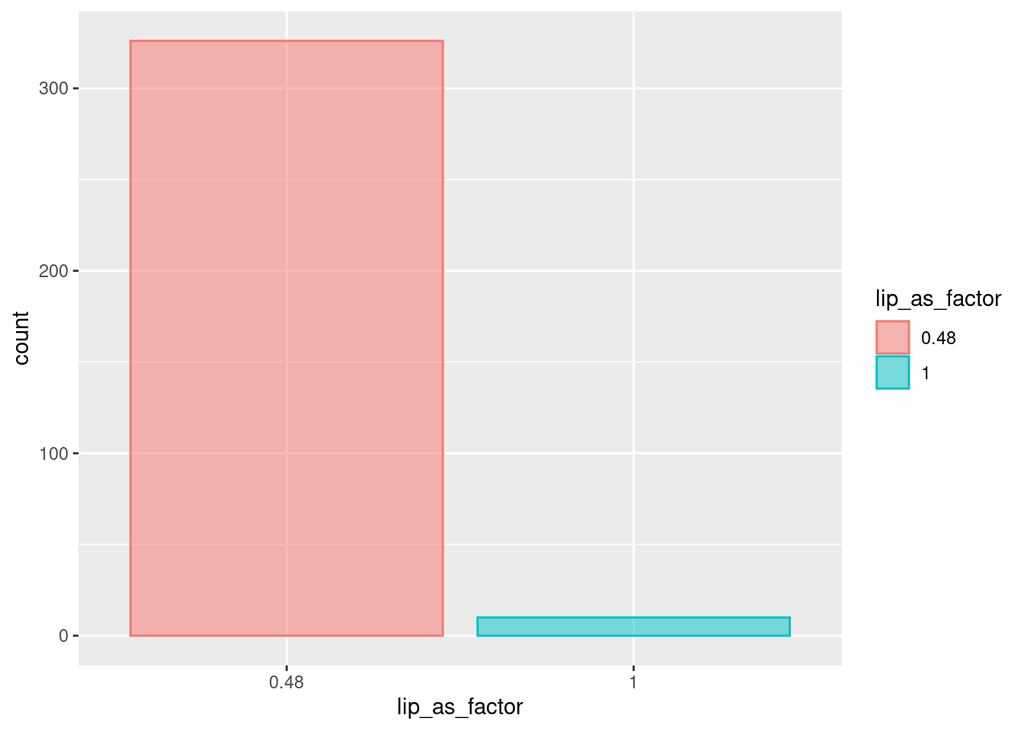

```r
df$lip_as_factor <- as.factor(df$lip)
ggplot(df, aes(x = lip_as_factor, color = lip_as_factor, fill = lip_as_factor)) + geom_bar(alpha = 0.5)
```

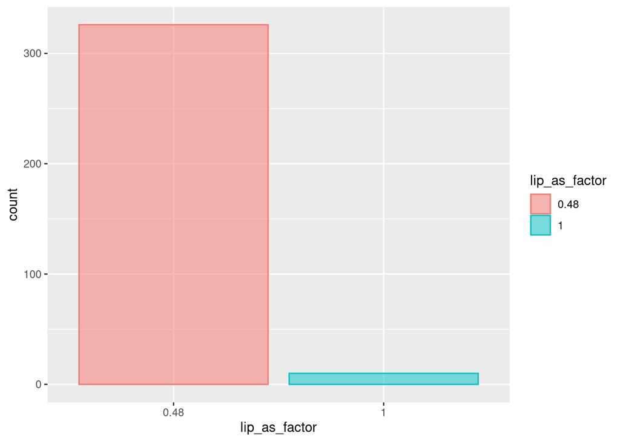

```r
ggplot(df, aes(x = lip_as_factor, color = lip_as_factor, fill = lip_as_factor)) + geom_bar(alpha = 0.5)
```

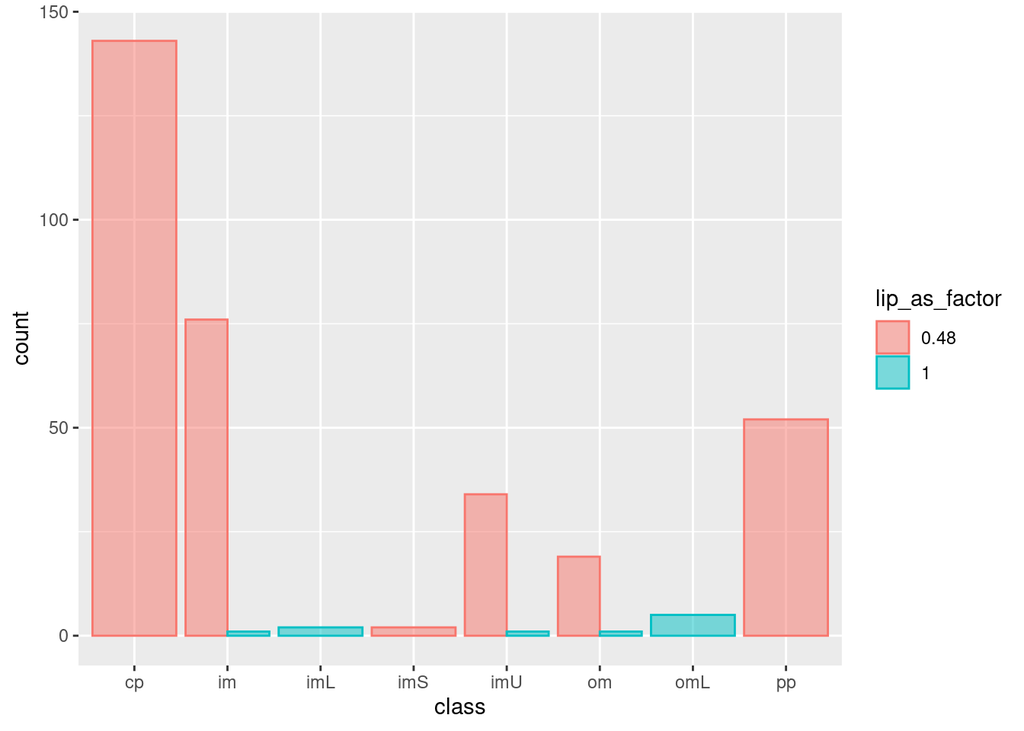

```r
ggplot(df, aes(x = class, color = lip_as_factor, fill = lip_as_factor)) + geom_bar(alpha = 0.5, position = "dodge")
```

```r
df$lip_as_factor <- NULL
```

## CHG (N-terminus Charge)

The chg variable is qualitative in nature and captures whether there is a charge on the N-terminous.

```r
table(df$chg)
```

```
##
## 0.5   1
## 335   1
```

When compared to the class variable, the single non instance of a 1 occurred when the class variable was `imL`.

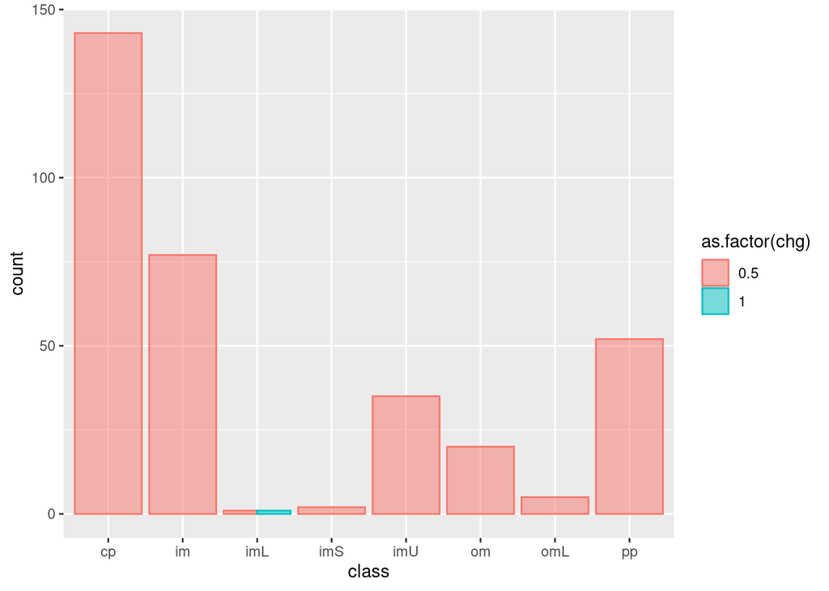

```r
ggplot(df, aes(x = class, color = as.factor(chg), fill = as.factor(chg))) + geom_bar(alpha = 0.5, position = "dodge")
```

## AAC (Score of Amino Acid Membrane and Protiens)

The aac variable is quantitative in nature and captures the score of discriminant analysis of the amino acid content of outer membrane and periplasmic proteins.

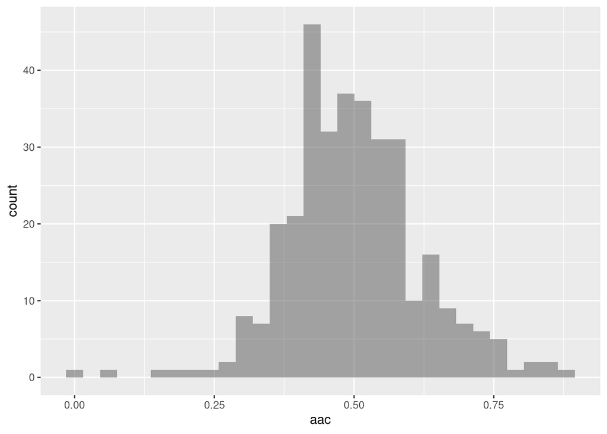

```r
ggplot(df, aes(x = aac)) + geom_histogram(alpha = 0.5)
```

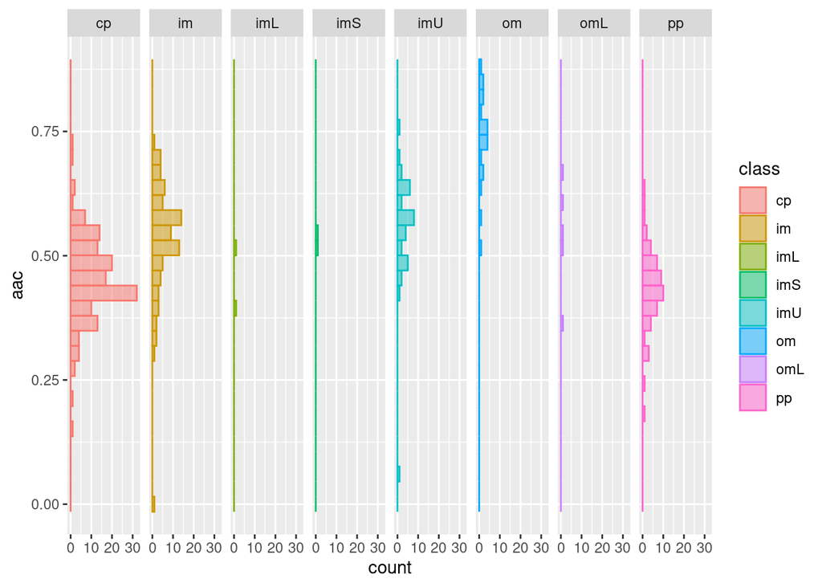

```r
ggplot(df, aes(x = aac, fill = class, color = class)) + geom_histogram(alpha = 0.5) + facet_grid(~ class) + coord_flip()
```

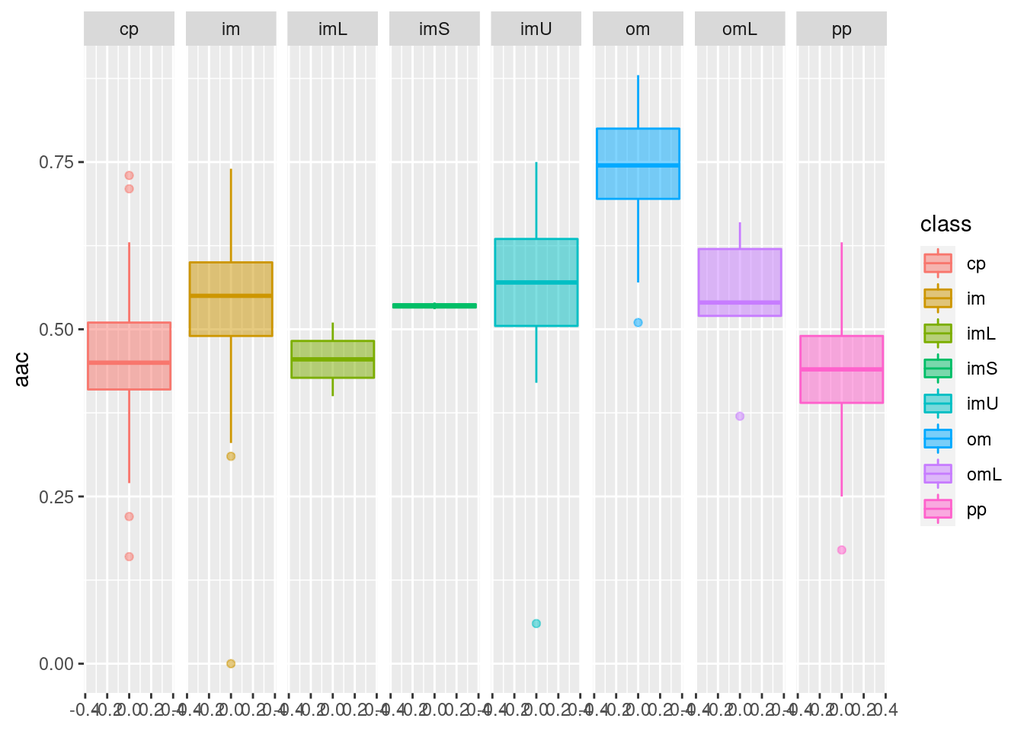

```r
ggplot(df, aes(x = aac, fill = class, color = class)) + geom_boxplot(alpha = 0.5) + facet_grid(~ class) + coord_flip()
```

## alm1

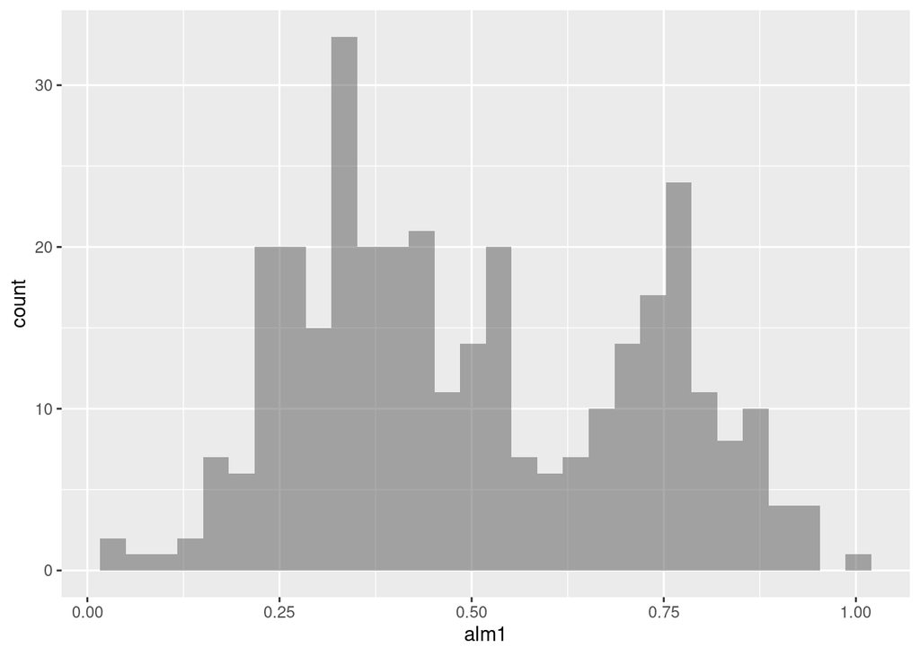

```r
ggplot(df, aes(x = alm1)) + geom_histogram(alpha = 0.5)
```

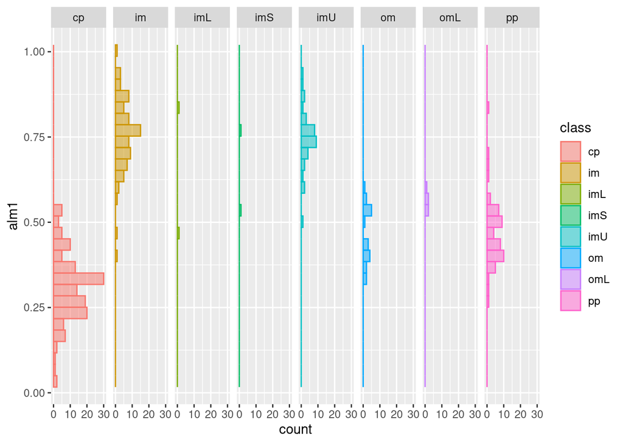

```r
ggplot(df, aes(x = alm1, fill = class, color = class)) + geom_histogram(alpha = 0.5) + facet_grid(~ class) + coord_flip()
```

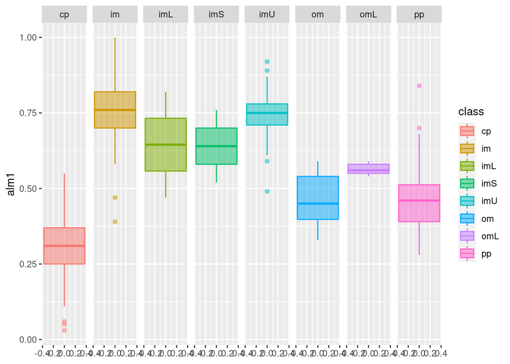

```r
ggplot(df, aes(x = alm1, fill = class, color = class)) + geom_boxplot(alpha = 0.5) + facet_grid(~ class) + coord_flip()
```

## alm2

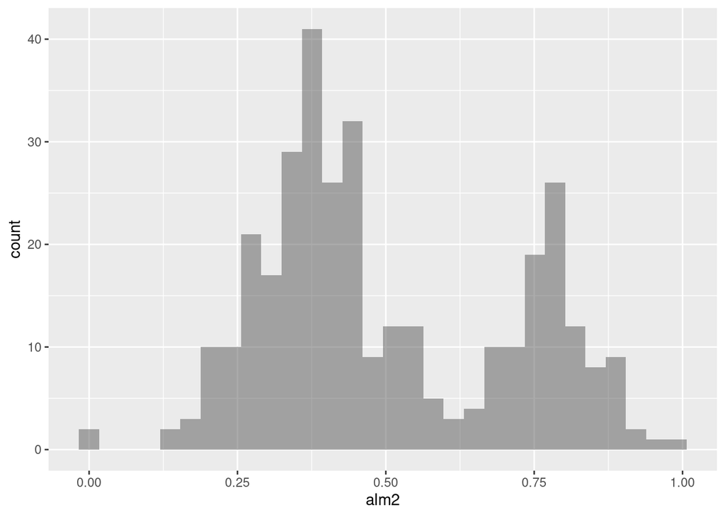

```r
ggplot(df, aes(x = alm2)) + geom_histogram(alpha = 0.5)
```

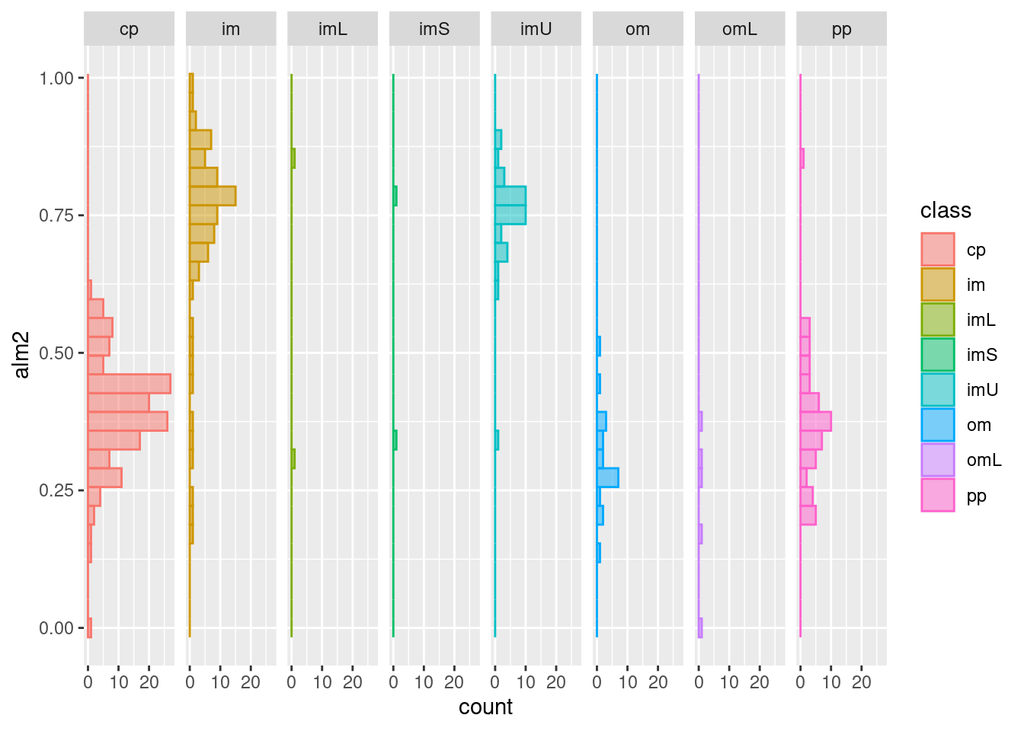

```r
ggplot(df, aes(x = alm2, fill = class, color = class)) + geom_histogram(alpha = 0.5) + facet_grid(~ class) + coord_flip()
```

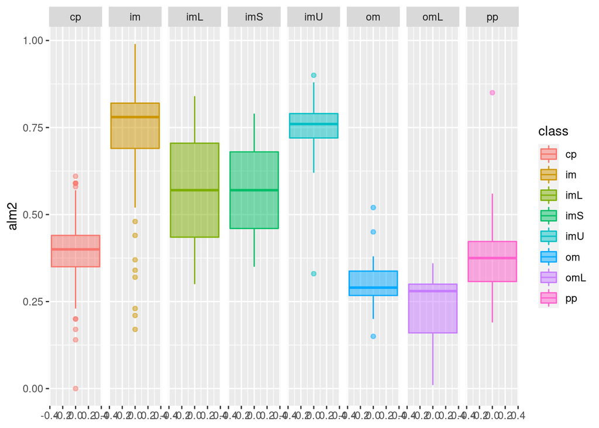

```r
ggplot(df, aes(x = alm2, fill = class, color = class)) + geom_boxplot(alpha = 0.5) + facet_grid(~ class) + coord_flip()
```